# Exploratory Analysis for Russian MoTR Reading Data

```r
shhh <- suppressPackageStartupMessages # It's a library, so shhh!

shhh(library( mgcv ))
shhh(library(dplyr))
shhh(library(ggplot2))
shhh(library(lme4))
shhh(library(tidymv))
shhh(library(gamlss))
shhh(library(gsubfn))
shhh(library(lmerTest))
shhh(library(tidyverse))
shhh(library(boot))
shhh(library(rsample))
shhh(library(plotrix))
shhh(library(ggrepel))
shhh(library(mgcv))
shhh(library(brms))
shhh(library(bayesplot))
shhh(library(tidyr))
shhh(library(car))
shhh(library(coda))
shhh(library(gridExtra))
shhh(library(posterior))

shhh(library(cmdstanr))
shhh(library(rstan))
shhh(library(rstantools))

rstan_options(auto_write=TRUE)
options(mc.cores=parallel::detectCores())
rstan_options(auto_write = TRUE)
theme_set(theme_bw())
options(digits=4)
options(scipen=999)
set.seed(444)
```

# Read in MoTR Data

```r
# The path to the data
data_path <- "./data/"
data_names <- list.files(data_path)

# Read in the data from each participant and add to the data frame
motr_df <- data.frame()
for(name in data_names){
  subj <- gsub("reader_", "", gsub("_reading_measures.csv", "", name))
  temp_df <- read.csv(paste0(data_path, "/", name)) %>% mutate(subj_id = subj)
  motr_df <- rbind(motr_df, temp_df)
}


# Turn the data into a tidy dataframe and clean the data
clean_df <- motr_df %>%
  filter(! list %in% c(98, 99)) %>% # filter practice and filler items
  mutate(skip = ifelse(total_duration==0, 1, 0),
         FPReg = ifelse(gaze_duration==0, NA, FPReg),
         FPFix = ifelse(gaze_duration==0, NA, FPFix)) %>%
  filter(skip == 0) %>%

  gather(measure, value, 18:26) %>%
  mutate(tgt_zero = if_else(measure %in% c("first_duration", "gaze_duration", "go_past_time", "right_bounded_rt", "total_duration") & value == 0, F, T)) %>%
  filter(tgt_zero != F) %>%
  dplyr::select(-tgt_zero, -cond_id, -skip) %>%
  mutate(item_id = as.factor(item_id),
         subj_id = as.factor(subj_id)) %>%
  mutate(cond = case_when(
    target_gender == "M" & gender_match == "Mis" & type == "stim_adj" ~ "a",
    target_gender == "M" & gender_match == "Mis" & type == "stim_verb" ~ "b",
     target_gender == "M" & gender_match == "Mis" & type == "stim_pred_adj" ~ "c",
    target_gender == "M" & gender_match == "Match" & type == "stim_adj" ~ "d",
    target_gender == "M" & gender_match == "Match" & type == "stim_verb" ~ "e",
    target_gender == "M" & gender_match == "Match" & type == "stim_pred_adj" ~ "f",
    target_gender == "F" & gender_match == "Mis" & type == "stim_adj" ~ "g",
    target_gender == "F" & gender_match == "Mis" & type == "stim_verb" ~ "h",
    target_gender == "F" & gender_match == "Mis" & type == "stim_pred_adj" ~ "i",
    target_gender == "F" & gender_match == "Match" & type == "stim_adj" ~ "j",
    target_gender == "F" & gender_match == "Match" & type == "stim_verb" ~ "k",
    target_gender == "F" & gender_match == "Match" & type == "stim_pred_adj" ~ "l",
    TRUE ~ NA_character_ # This is the default case if none of the above conditions are met
  )) %>%
  dplyr::select(-list, -part, -type, -type_id, -target_gender, -gender_match, -orig_item_number, -case, -animacy, -AOI_id, -word, -response_true, -response_chosen, -correctness)

View(clean_df)
```

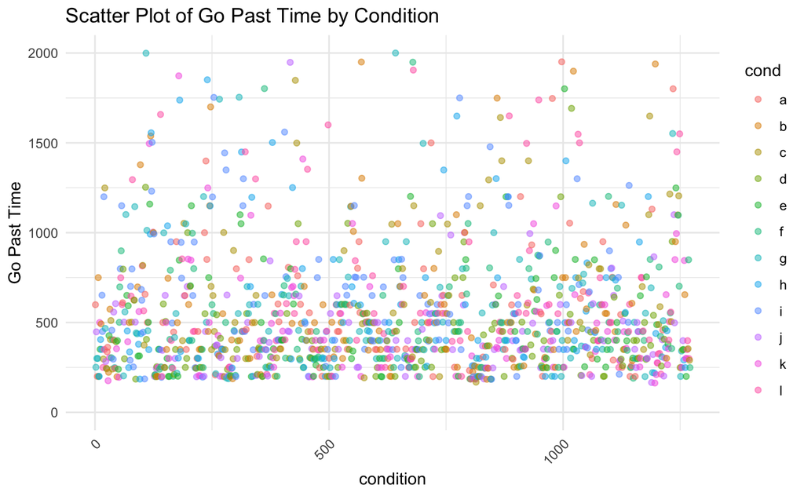

```r
clean_df %>% filter(word_nr == 3) %>%
  filter(measure == "go_past_time") %>%
  mutate(index = row_number()) %>%
  ggplot(., aes(x = index, y = value, color = cond)) +
  geom_point(alpha = 0.5) +  # Adjust alpha for better visualization if points overlap
  labs(x = "condition", y = "Go Past Time", title = "Scatter Plot of Go Past Time by Condition") +
  theme_minimal() +
  theme(axis.text.x = element_text(angle = 45, hjust = 1)) +
  ylim(0, 2000)  # Set y-axis limits from 0 to 2000
```

### RESEARCH QUESTIONS:

1. Are RTs different in gender-match versus gender-mismatch sentences? ==> main effect of grammaticality (gender match or not)
2. Are RTs different in Masculine versus Feminine sentence conditions? ==> main effect of gender of target word
3. Are RTs affected by sentence type (whether different lexical categories of the agreeing element will make the processing more difficult or not)? –> ADJ(adj + pre_adj) v.s. VERB ==> main effect of lexical type of sentences.
4. Are RTs affected by sentence type (whether agreeing element instantiates internal v.s. external agreement will make a difference in processing difficulty)? –> internal (modifying adjective) v.s. external (verb or predicative adjective) ==> main effect of syntax type of sentences.
5. Does the grammaticality effect within each lexical sentence type differ from each other? –> Whether the effect of grammaticality depends on the lexical type of the sentence (ADJ? VERB?) ==> interaction between grammaticality and lexical sentence type

6.Does the grammaticality effect within each syntax sentence type differ from each other? –> Whether the effect of grammaticality depends on the syntax type of the sentence (internal? external?) ==> interaction between grammaticality and syntax sentence type

7. Does the (possible) difference in the sensitivity to the grammaticality manipulation of Masculine versus Feminine conditions differ between lexical sentence types (ADJ v.s. VERB)? ==> 3-way interaction between grammaticality, gender and lexical sentence type
8. Does the (possible) difference in the sensitivity to the grammaticality manipulation of Masculine versus Feminine conditions differ between syntax sentence types (internal v.s. external)? ==> 3-way interaction between grammaticality, gender and syntax sentence type

# contrast coding

```r
# check conditions
clean_df$cond <- factor(clean_df$cond)
summary(clean_df$cond)
```

```
   a    b    c    d    e    f    g    h    i    j    k    l
5991 6261 5757 6378 6471 6186 6195 6267 7596 5643 5679 6957
```

```r
clean_df <- clean_df %>%
  mutate(
    #--------------------- main effects ---------------------
    Gram = ifelse(cond %in% c('a', 'b', 'c', 'g', 'h', 'i'), 1/6, -1/6), # Main effect grammaticality
    Gen = ifelse(cond %in% c('a','b','c','d','e', 'f'), 1/6, -1/6), # Main effect gender
    TypL = ifelse(cond %in% c('a','c','d','f', 'g', 'i', 'j', 'l'), 1/8, -1/4), # Main effect of sentence type (ap vs v)
    TypS = ifelse(cond %in% c('a', 'd', 'g', 'j'), 1/4, -1/8), # Main effect of sentence type (a vs pv)

    #--------------------- 2 way interection ---------------------
    # Gram_x_TypL = ifelse(cond %in% c('a', 'c', 'i'), 1/8,
    #                  ifelse(cond %in% c('d', 'f', 'l'), -1/8,
    #                    ifelse(cond %in% c('e', 'k'), 1/4, -1/4))), # Grammaticality x type (ap v)

    # Gram_x_TypS = ifelse(cond %in% c('e', 'f', 'k', 'l'), 1/8,
    #                   ifelse(cond %in% c('b', 'c', 'h', 'i'), -1/8,
    #                          ifelse(cond %in% c('a', 'g'), 1/4, -1/4))), # Grammaticality x type (ap v)
    Gram_x_TypL = ifelse(cond %in% c('a', 'c', 'g', 'i', 'e', 'k'), 1/2, -1/2), # Grammaticality x type (ap v)
    Gram_x_TypS = ifelse(cond %in% c('a', 'g', 'e', 'f', 'k', 'l'), 1/2, -1/2), # Grammaticality x type (ap v)

    Gram_TypL_M = ifelse(cond %in% c('a', 'c', 'e'), 1/2,
                    ifelse(cond %in% c('b', 'd', 'f'), -1/2, 0)), # gram x typl(ap v)_M
    Gram_TypS_M = ifelse(cond %in% c('a', 'e', 'f'), 1/2,
                ifelse(cond %in% c('b', 'c', 'd'), -1/2, 0)), # gram x typs(a pv)_M
    Gram_TypL_F = ifelse(cond %in% c('g', 'i', 'k'), 1/2,
                ifelse(cond %in% c('h', 'j', 'l'), -1/2, 0)), # gram x typl(ap v)_F
    Gram_TypS_F = ifelse(cond %in% c('a', 'e', 'f'), 1/2,
                ifelse(cond %in% c('b', 'c', 'd'), -1/2, 0)), # gram x typs(a pv)_F

    #--------------------- 3 way interection ---------------------
    Gram_x_Gen_x_TypL = ifelse(cond %in% c('a', 'c', 'e', 'h', 'j', 'l'), 1/2, -1/2), # gen x typ1(ap v) x gram
    Gram_x_Gen_x_TypS = ifelse(cond %in% c('a', 'e', 'f', 'h', 'i', 'j'), 1/2, -1/2), # gen x typ1(ap v) x gram

    #--------------------- Within grammaticality type effects ---------------------
    Typ_Mis = ifelse(cond %in% c('a', 'c', 'g', 'i'), 1/4,
              ifelse(cond %in% c('b', 'h'), -1/2, 0)),  # type_Mis
    Typ_Match = ifelse(cond %in% c('d', 'f', 'j', 'l'), 1/4,
                  ifelse(cond %in% c('e', 'k'), -1/2, 0))  # type_Match
  ) %>% spread(measure, value) %>%
  filter(word_nr == 3)

clean_df
```

| item_id | word_nr | subj_id | cond | Gram | Gen | TypL | TypS | Gram_x_TypL | Gram_x_TypS | Gram_TypL_M | Gram_TypS_M | Gram_TypL_F | Gram_TypS_F | Gram_x_Gen_x_TypL | Gram_x_Gen_x_TypS | Typ_Mis | Typ_Match | first_duration | FPFix | FPReg | gaze_duration | go_past_time | RegIn_excl | RegIn_incl | right_bounded_rt | total_duration |
| --- | --- | --- | --- | --- | --- | --- | --- | --- | --- | --- | --- | --- | --- | --- | --- | --- | --- | --- | --- | --- | --- | --- | --- | --- | --- | --- |
| 4 | 3 | 131 | a | 0.1667 | 0.1667 | 0.125 | 0.250 | 0.5 | 0.5 | 0.5 | 0.5 | 0.0 | 0.5 | 0.5 | 0.5 | 0.25 | 0.00 | 599 | 1 | 0 | 599 | 599 | 0 | 0 | 599 | 599 |
| 6 | 3 | 131 | g | 0.1667 | -0.1667 | 0.125 | 0.250 | 0.5 | 0.5 | 0.0 | 0.0 | 0.5 | 0.0 | -0.5 | -0.5 | 0.25 | 0.00 | 251 | 1 | 0 | 251 | 251 | 0 | 0 | 251 | 251 |
| 7 | 3 | 131 | j | -0.1667 | -0.1667 | 0.125 | 0.250 | -0.5 | -0.5 | 0.0 | 0.0 | -0.5 | 0.0 | 0.5 | 0.5 | 0.00 | 0.25 | 448 | 1 | 0 | 448 | 448 | 0 | 0 | 448 | 448 |
| 14 | 3 | 131 | g | 0.1667 | -0.1667 | 0.125 | 0.250 | 0.5 | 0.5 | 0.0 | 0.0 | 0.5 | 0.0 | -0.5 | -0.5 | 0.25 | 0.00 | 300 | 1 | 0 | 300 | 300 | 0 | 0 | 300 | 300 |
| 16 | 3 | 131 | a | 0.1667 | 0.1667 | 0.125 | 0.250 | 0.5 | 0.5 | 0.5 | 0.5 | 0.0 | 0.5 | 0.5 | 0.5 | 0.25 | 0.00 | 200 | 1 | 0 | 200 | 200 | 1 | 1 | 200 | 3492 |
| 18 | 3 | 131 | g | 0.1667 | -0.1667 | 0.125 | 0.250 | 0.5 | 0.5 | 0.0 | 0.0 | 0.5 | 0.0 | -0.5 | -0.5 | 0.25 | 0.00 | 300 | 1 | 0 | 300 | 300 | 0 | 0 | 300 | 300 |
| 20 | 3 | 131 | b | 0.1667 | 0.1667 | -0.250 | -0.125 | -0.5 | -0.5 | -0.5 | -0.5 | 0.0 | -0.5 | -0.5 | -0.5 | -0.50 | 0.00 | 550 | 1 | 1 | 550 | 750 | 0 | 0 | 550 | 550 |
| 21 | 3 | 131 | e | -0.1667 | 0.1667 | -0.250 | -0.125 | 0.5 | 0.5 | 0.5 | 0.5 | 0.0 | 0.5 | 0.5 | 0.5 | 0.00 | -0.50 | 200 | 1 | 0 | 200 | 200 | 0 | 0 | 200 | 200 |
| 22 | 3 | 131 | h | 0.1667 | -0.1667 | -0.250 | -0.125 | -0.5 | -0.5 | 0.0 | 0.0 | -0.5 | 0.0 | 0.5 | 0.5 | -0.50 | 0.00 | 200 | 1 | 0 | 200 | 200 | 0 | 0 | 200 | 200 |
| 23 | 3 | 131 | k | -0.1667 | -0.1667 | -0.250 | -0.125 | 0.5 | 0.5 | 0.0 | 0.0 | 0.5 | 0.0 | -0.5 | -0.5 | 0.00 | -0.50 | 500 | 1 | 0 | 500 | 500 | 0 | 0 | 500 | 500 |

[output cut: 990 more lines]

```r
stats_df = data.frame()
measure_types = c("gaze_duration", "go_past_time", "total_duration",
                  "FPReg", "RegIn_incl"
                  )

for (meas in measure_types){
  print(paste("Fitting model for:", meas))

  if (meas %in% c("gaze_duration", "go_past_time", "total_duration")){
      model <- clean_df %>% filter(!is.na(.[[meas]]))  %>%
        lmer(as.formula(paste(meas, "~ Gram + Gen + TypL + TypS +
            Gram_x_TypL + Gram_x_TypS + Gram_x_Gen_x_TypL + Gram_x_Gen_x_TypS +
            (Gram | item_id) + (Gram | subj_id)")),
            data = ., REML = F)
      coefs <- summary(model)$coefficients
      temp_results <- data.frame(
        measure = meas,
        beta = c("b_0", "b_Gram", "b_Gen", "b_TypL", "b_TypS", "b_Gram_x_TypL", "b_Gram_x_TypS", "b_Gram_x_Gen_x_TypL", "b_Gram_x_Gen_x_TypS"),
        bval = coefs[, "Estimate"],
        pval = coefs[, "Pr(>|t|)"]
      )
  }else{
      model <- clean_df %>% filter(!is.na(.[[meas]]))  %>%
        glmer(as.formula(paste(meas, "~ Gram + Gram_x_TypL + Gram_x_TypS + Gram_x_Gen_x_TypL + Gram_x_Gen_x_TypS +
            (1 | item_id) + (1 | subj_id)")),
            data = ., family=binomial(link = "logit"))
      coefs <- summary(model)$coefficients
      temp_results <- data.frame(
        measure = meas,
        beta = c("b_0", "b_Gram", "b_Gram_x_TypL", "b_Gram_x_TypS", "b_Gram_x_Gen_x_TypL", "b_Gram_x_Gen_x_TypS"),
        bval = coefs[, "Estimate"],
        pval = coefs[, "Pr(>|z|)"]
        )
  }
    stats_df = rbind(stats_df, temp_results)
}

stats_df = stats_df %>%
  mutate(sig = if_else(pval < 0.05, "SIG", ifelse(pval < .1, ".", "")))

# stats_df

write.csv(stats_df, "./stats/stats_lmer.csv", row.names = FALSE)

# m_gd <- clean_df %>%
#   filter(!is.na(FPReg)) %>%
#   glmer(FPReg ~ Gram + Gram_x_TypL+ Gram_x_TypS + Gram_x_Gen_x_TypL + Gram_x_Gen_x_TypS +
#          (1 | item_id ) + (1 | subj_id ), data = ., family=binomial(link = "logit"))
# summary(m_gd)$coefficients
```

# function for creating stan data format

```r
createStanDat<-function(d, dv,form){

  subj <- as.integer(factor(d$subj))
  N_subj <- length(unique(subj))
  item <- as.integer(factor(d$item))
  N_items <- length(unique(item))
  X <- unname(model.matrix(form, d))
  attr(X, which="assign") <- NULL

  stanDat <- list(N = nrow(X),
                  P = ncol(X),
                  n_u = ncol(X),
                  n_w = ncol(X),
                  X = X,
                  Z_u = X,
                  Z_w = X,
                  J = N_subj,
                  K = N_items,
                  dv = dv,
                  subj = subj,
                  item = item)
  stanDat
}
```

```r
stan_gd <- createStanDat(d=subset(clean_df, !is.na(clean_df$gaze_duration)),
                             form=as.formula("~1+Gram+Gen+TypL+TypS+Gram_x_TypL+Gram_x_TypS+Gram_x_Gen_x_TypL+Gram_x_Gen_x_TypS"),
                             dv=subset(clean_df, !is.na(clean_df$gaze_duration))$gaze_duration)

m1_gd <- stan(file = "stan/maxModel1.stan",
                data = stan_gd,
                iter = 4000,
                chains = 4,
                control = list(adapt_delta=0.99))
saveRDS(m1_gd, file = "model/m1_gd.rds")
```

```r
stan_gpt <- createStanDat(d=subset(clean_df, !is.na(clean_df$go_past_time)),
                             form=as.formula("~1+Gram+Gen+TypL+TypS+Gram_x_TypL+Gram_x_TypS+Gram_x_Gen_x_TypL+Gram_x_Gen_x_TypS"),
                             dv=subset(clean_df, !is.na(clean_df$go_past_time))$go_past_time)

# sample from posterior distribution.
m1_gpt <- stan(file = "stan/maxModel1.stan",
                data = stan_gpt,
                iter = 4000,
                chains = 4,
                control = list(adapt_delta=0.99))
saveRDS(m1_gpt, file = "model/m1_gpt.rds")
```

```r
stan_td <- createStanDat(d=subset(clean_df, !is.na(clean_df$total_duration)),
                             form=as.formula("~1+Gram+Gen+TypL+TypS+Gram_x_TypL+Gram_x_TypS+Gram_x_Gen_x_TypL+Gram_x_Gen_x_TypS"),
                             dv=subset(clean_df, !is.na(clean_df$total_duration))$total_duration)

# sample from posterior distribution.
m1_td <- stan(file = "stan/maxModel1.stan",
                data = stan_td,
                iter = 4000,
                chains = 4,
                control = list(adapt_delta=0.99))
saveRDS(m1_td, file = "model/m1_td.rds")
```

# binary dv

```r
stan_fpreg <- createStanDat(d=subset(clean_df, !is.na(clean_df$FPReg)),
                             form=as.formula("~1+Gram+Gen+TypL+TypS+Gram_x_TypL+Gram_x_TypS+Gram_x_Gen_x_TypL+Gram_x_Gen_x_TypS"),
                             dv=subset(clean_df, !is.na(clean_df$FPReg))$FPReg)

# sample from posterior distribution.
m1_fpreg <- stan(file = "stan/logitModel1.stan",
                data = stan_fpreg,
                iter = 4000,
                chains = 4,
                control = list(adapt_delta=0.99))
saveRDS(m1_fpreg, file = "model/m1_fpreg.rds")
```

```r
stan_regin <- createStanDat(d=subset(clean_df, !is.na(clean_df$RegIn_incl)),
                             form=as.formula("~1+Gram+Gen+TypL+TypS+Gram_x_TypL+Gram_x_TypS+Gram_x_Gen_x_TypL+Gram_x_Gen_x_TypS"),
                             dv=subset(clean_df, !is.na(clean_df$RegIn_incl))$RegIn_incl)

# sample from posterior distribution.
m1_regin <- stan(file = "stan/logitModel1.stan",
                data = stan_regin,
                iter = 4000,
                chains = 4,
                control = list(adapt_delta=0.99))
saveRDS(m1_regin, file = "model/m1_regin.rds")
```

# Examine fitted stan models

[figure not shown]

# compile model results

```r
stats_df <- data.frame()

# Define the measure types corresponding to your models
measure_types <- c("gaze_duration", "go_past_time", "total_duration", "FPReg", "RegIn_incl")

# Loop over each measure type to read the corresponding model and extract data
for (meas in measure_types) {
  if (meas == "gaze_duration") {
      m1 <- readRDS("model/m1_gd.rds")
    } else if (meas == "go_past_time") {
      m1 <- readRDS("model/m1_gpt.rds")
    } else if (meas == "total_duration") {
      m1 <- readRDS("model/m1_td.rds")
    } else if (meas == "FPReg") {
      m1 <- readRDS("model/m1_fpreg.rds")
    } else if (meas == "RegIn_incl") {
      m1 <- readRDS("model/m1_regin.rds")
    }

  # Extract posterior distributions
  y_posterior <- extract(m1)
  intercept <- exp(y_posterior$beta[,1])

  betas <- c("b_0", "b_Gram", "b_Gen", "b_TypL", "b_TypS", "b_Gram_x_TypL", "b_Gram_x_TypS", "b_Gram_x_Gen_x_TypL", "b_Gram_x_Gen_x_TypS")
  posterior_samples <- list(intercept, y_posterior$Gram, y_posterior$Gen, y_posterior$TypL, y_posterior$TypS,    y_posterior$Gram_x_TypL, y_posterior$Gram_x_TypS, y_posterior$Gram_x_Gen_x_TypL, y_posterior$Gram_x_Gen_x_TypS)

  # Prepare the results data frame
  temp_results <- data.frame(
    measure = rep(meas, length(betas)),
    beta = betas,
    bval_mean = sapply(posterior_samples, mean),
    crI_95_lower = sapply(posterior_samples, function(x) quantile(x, 0.025)),
    crI_95_upper = sapply(posterior_samples, function(x) quantile(x, 0.975)),
    crl_89_lower = sapply(posterior_samples, function(x) quantile(x, 0.055)),
    crl_89_upper = sapply(posterior_samples, function(x) quantile(x, 0.945)),
    bval_median = sapply(posterior_samples, median)
  )

  # Append the temp_results to the stats_df data frame
  stats_df <- rbind(stats_df, temp_results)
}

write.csv(stats_df, "./stats/stats_bayesian.csv", row.names = FALSE)
```

### OBSERVATIONS:

gpt, gd, td, reg:

1. Effects of Grammaticality are always significant. –> There are main effect of grammaticality (gender match or not).
2. Effects of condTypS are significant or nearly significant. –> Very likely, there are main effect of syntactic agreement type (adj vs verb & pred_adj)
3. The significance of condTypL is always smaller than condTypS. In Bayesian, the crI of beta for TypL (diff between adj vs verb) is always larger and 0 is more to the middle of its distribution.
- If do sum contrast for each level of type, pred_adj type is significantly different from the grand mean.
4. For gd, the interaction between TypS and Gram is significant. For td and gpt, it is also near to significance (or 0 to be in the narrow tail of its distr. in Bayesian). –> external or internal agreement will affect the process of mismatches in sentence.
5. Interaction between TypL and Gram is far from significance.
6. In td, there are three way interaction between TypL & Gram & Gen. –> coincidence?

### CONCLUSION:

1. Longer rt and more regressions in error setences.
2. Longer rt and possibly more regressions in external agreement than internal ones. –> external is more difficult.
3. But rt difference between mismatch and match is bigger in internal than in external. –> internal agreement kind of amplify the processing difficulty in mismatches. Maybe because external sentences are already difficult, so when combined with errors, the rt is not that different from in correct sentence. Maybe because people have their upboundary for the times they spend on difficult sentences? –> obviously, rt(difficult_external_type + error_sentence) < rt(difficult_external_type_sentence) + rt(error_sentence)

```r
# Create an aggregate DF with mean and 95% CIs for each condition and sentence region

df = motr_df %>%
  filter(! list %in% c(98, 99)) %>% # filter practice and filler items
  mutate(skip = ifelse(total_duration==0, 1, 0),
         FPReg = ifelse(gaze_duration==0, NA, FPReg),
         FPFix = ifelse(gaze_duration==0, NA, FPFix)) %>%
  filter(skip == 0) %>%

  gather(measure, value, 18:26) %>%
  mutate(tgt_zero = if_else(measure %in% c("first_duration", "gaze_duration", "go_past_time", "right_bounded_rt", "total_duration") & value == 0, F, T)) %>%
  filter(tgt_zero != F) %>%
  drop_na() %>%
  dplyr::select(-tgt_zero, -cond_id, -skip) %>%

  mutate(word_nr = if_else(word_nr > 4, 4, as.double(word_nr))) %>%
  rename(region = word_nr) %>%
  #mutate(region=factor(region, levels=c("pre-critical", "critical", "post-critical", "end"))) %>%
  mutate(type_s = ifelse(type %in% c('stim_adj'), "Modifying_Adj", "Predictive_Adj_Verb"),
         type_l = ifelse(type %in% c('stim_verb'), "Verb", "Modifying_Adj_Predictive_Adj")
         ) %>%
  drop_na() %>%
  group_by(measure) %>%
    mutate(outlier = value > (mean(value) + 3 * sd(value))) %>%
  ungroup() %>%
  mutate(outlier_discard = if_else(measure %in% c("first_duration", "gaze_duration", "total_duration", "go_past_time", "right_bounded_rt") & outlier == T, F, T)) %>%
  filter(outlier_discard == T) %>%
  dplyr::select(-outlier_discard) %>%
  drop_na()

# View(df)

agg_df = df %>%
  group_by(type_s, gender_match, region, measure) %>%
    summarise(
      m = mean(value),
      s = std.error(value),
      lower = m - 1.96 * s,
      upper = m + 1.96 * s
    ) %>%
  ungroup()

agg_df
```

```r
# Create an aggregate DF with mean and 95% CIs for each condition and sentence region


df = motr_df %>%
  filter(! list %in% c(98, 99)) %>% # filter practice and filler items
  mutate(skip = ifelse(total_duration==0, 1, 0),
         FPReg = ifelse(gaze_duration==0, NA, FPReg),
         FPFix = ifelse(gaze_duration==0, NA, FPFix)) %>%
  filter(skip == 0) %>%

  gather(measure, value, 18:26) %>%
  mutate(tgt_zero = if_else(measure %in% c("first_duration", "gaze_duration", "go_past_time", "right_bounded_rt", "total_duration") & value == 0, F, T)) %>%
  filter(tgt_zero != F) %>%
  drop_na() %>%
  dplyr::select(-tgt_zero, -cond_id, -skip) %>%

  mutate(word_nr = if_else(word_nr > 4, 4, as.double(word_nr))) %>%
  rename(region = word_nr) %>%
  #mutate(region=factor(region, levels=c("pre-critical", "critical", "post-critical", "end"))) %>%
  mutate(type_s = ifelse(type %in% c('stim_adj'), "Modifying_Adj", "Predictive_Adj_Verb"),
         type_l = ifelse(type %in% c('stim_verb'), "Verb", "Modifying_Adj_Predictive_Adj")
         ) %>%
  drop_na() %>%
  group_by(measure) %>%
    mutate(outlier = value > (mean(value) + 3 * sd(value))) %>%
  ungroup() %>%
  mutate(outlier_discard = if_else(measure %in% c("first_duration", "gaze_duration", "total_duration", "go_past_time", "right_bounded_rt") & outlier == T, F, T)) %>%
  filter(outlier_discard == T) %>%
  dplyr::select(-outlier_discard) %>%
  drop_na()

View(df)

agg_df = df %>%
  group_by(type_s, gender_match, region, measure) %>%
    summarise(
      m = mean(value),
      s = std.error(value),
      lower = m - 1.96 * s,
      upper = m + 1.96 * s
    ) %>%
  ungroup()
agg_df
```

| type_s | gender_match | region | measure | m | s | lower | upper |
| --- | --- | --- | --- | --- | --- | --- | --- |
| Modifying_Adj | Match | 0 | FPFix | 1.00000 | 0.000000 | 1.000000 | 1.00000 |
| Modifying_Adj | Match | 0 | FPReg | 0.00000 | 0.000000 | 0.000000 | 0.00000 |
| Modifying_Adj | Match | 0 | RegIn_excl | 0.03759 | 0.016556 | 0.005145 | 0.07004 |
| Modifying_Adj | Match | 0 | RegIn_incl | 0.17293 | 0.032917 | 0.108415 | 0.23745 |
| Modifying_Adj | Match | 0 | first_duration | 389.13534 | 16.403646 | 356.984192 | 421.28648 |
| Modifying_Adj | Match | 0 | gaze_duration | 397.41739 | 17.571061 | 362.978112 | 431.85667 |
| Modifying_Adj | Match | 0 | go_past_time | 397.41739 | 17.571061 | 362.978112 | 431.85667 |
| Modifying_Adj | Match | 0 | right_bounded_rt | 397.41739 | 17.571061 | 362.978112 | 431.85667 |
| Modifying_Adj | Match | 0 | total_duration | 403.54135 | 17.963145 | 368.333589 | 438.74912 |
| Modifying_Adj | Match | 1 | FPFix | 1.00000 | 0.000000 | 1.000000 | 1.00000 |

[output cut: 170 more lines]

```r
NA
```

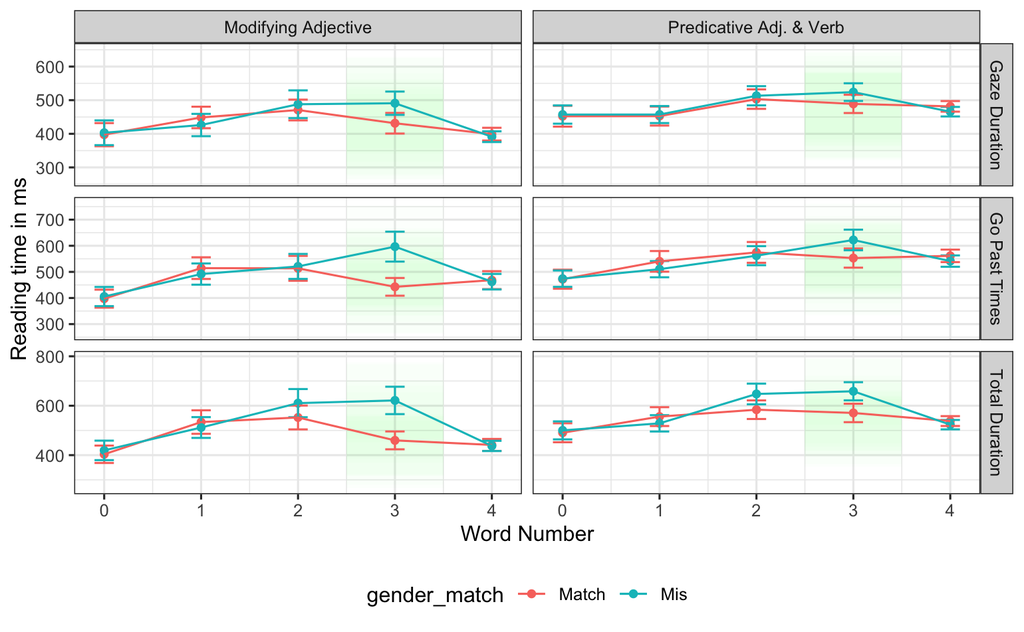

```r
# Plot the reading times in each region broken down by stimulus type, reading measure and target gender

agg_df %>%
  # filter(type_s %in% c("stim_adj", "stim_verb", "stim_pred_adj")) %>%
  filter(measure %in% c("gaze_duration", "go_past_time", "total_duration")) %>%

  mutate(type_s = factor(type_s, levels = c("Modifying_Adj", "Predictive_Adj_Verb"), labels=c("Modifying Adjective", "Predicative Adj. & Verb"))) %>%
  mutate(measure = factor(measure, levels = c("gaze_duration", "go_past_time", "total_duration"), labels=c("Gaze Duration", "Go Past Times", "Total Duration"))) %>%

  ggplot(aes(x=region, y=m, color = gender_match)) +
    geom_rect(aes(xmin=2.5, xmax=3.5, ymin=lower-100, ymax=upper+100), color = NA, fill = "green", alpha=0.01) +
    geom_point() +
    geom_errorbar(aes(ymin=lower, ymax=upper), width = 0.2) +
    geom_line() +
    facet_grid(measure~type_s, scales = "free_y") +
    #ggtitle(paste0("Region by region plot for ", stim)) +
    ylab("Reading time in ms") +
    xlab("Word Number") +
  #coord_cartesian(ylim=c(0, 900)) +
  theme(
    legend.position = "bottom"
  )

ggsave(paste0("./images/RT_results_synt_position.pdf"), device="pdf", height=5, width=8)
```

```r
# ggsave(paste0("./images/RT_results.png"), height=5, width=8)
```

```r
agg_df2 = df %>%
  group_by(type_s, subj_id, region, measure) %>%
    summarise(
      m = mean(value),
    ) %>%
  ungroup() %>%
  group_by(type_s, region, measure) %>%
  pivot_wider(
    names_from = type_s,
    values_from = m,
    names_prefix = "mean_"
  ) %>%
  # Calculate the difference between 'Mis' and 'Match'
  drop_na() %>%
  mutate(
    diff = mean_Predictive_Adj_Verb - mean_Modifying_Adj
  ) %>%
  group_by(region, measure) %>%
  summarise(
    m_diff = mean(diff),
    s = std.error(diff),
    lower = m_diff - 1.96 * s,
    upper = m_diff + 1.96 * s
  ) %>%
  ungroup()
View(agg_df2)
```

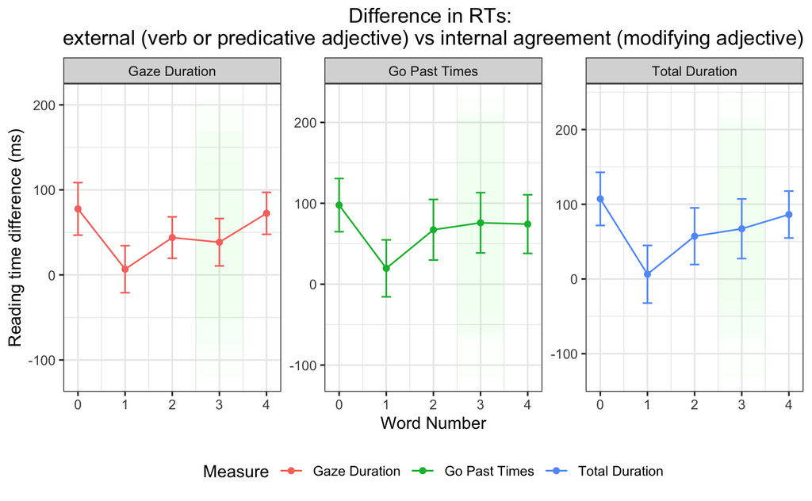

```r
# Plot the reading times in each region broken down by stimulus type, reading measure and target gender

agg_df2 %>%
  # filter(type_s %in% c("stim_adj", "stim_verb", "stim_pred_adj")) %>%
  filter(measure %in% c("gaze_duration", "go_past_time", "total_duration")) %>%
  mutate(measure = factor(measure, levels = c("gaze_duration", "go_past_time", "total_duration"), labels=c("Gaze Duration", "Go Past Times", "Total Duration"))) %>%

  ggplot(aes(x=region, y=m_diff, color = measure)) +
    geom_rect(aes(xmin=2.5, xmax=3.5, ymin=lower-100, ymax=upper+100), color = NA, fill = "green", alpha=0.01) +
    geom_point() +
    geom_errorbar(aes(ymin=lower, ymax=upper), width = 0.2) +
    geom_line() +
    facet_wrap(~ measure, scales = "free_y") +
    labs(
      title = "Difference in RTs: \nexternal (verb or predicative adjective) vs internal agreement (modifying adjective)",
      y = "Reading time difference (ms)",
      x = "Word Number",
      color = "Measure"
    ) +
  #coord_cartesian(ylim=c(0, 900)) +
  theme(
    legend.position = "bottom",
    plot.title = element_text(hjust = 0.5)
  )

ggsave(paste0("./images/RT_results_main_diff_in_synt.pdf"), device="pdf", height=5, width=8)
```

```r
# ggsave(paste0("./images/RT_results.png"), height=5, width=8)
```

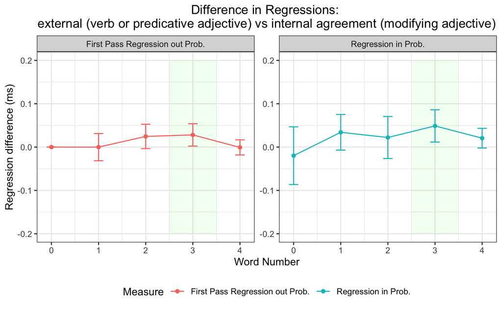

```r
# Plot the reading times in each region broken down by stimulus type, reading measure and target gender

agg_df2 %>%
  # filter(type_s %in% c("stim_adj", "stim_verb", "stim_pred_adj")) %>%
  filter(measure %in% c("FPReg", "RegIn_incl")) %>%
  mutate(measure = factor(measure, levels = c("FPReg", "RegIn_incl"), labels=c("First Pass Regression out Prob.", "Regression in Prob."))) %>%

  ggplot(aes(x=region, y=m_diff, color = measure)) +
    geom_rect(aes(xmin=2.5, xmax=3.5, ymin=-0.2, ymax=0.2), color = NA, fill = "green", alpha=0.01) +
    geom_point() +
    geom_errorbar(aes(ymin=lower, ymax=upper), width = 0.2) +
    geom_line() +
    facet_wrap(~ measure, scales = "free_y") +
    labs(
      title = "Difference in Regressions: \nexternal (verb or predicative adjective) vs internal agreement (modifying adjective)",
      y = "Regression difference (ms)",
      x = "Word Number",
      color = "Measure"
    ) +
  #coord_cartesian(ylim=c(0, 900)) +
  theme(
    legend.position = "bottom",
    plot.title = element_text(hjust = 0.5)
  )

ggsave(paste0("./images/Reg_results_main_diff_in_synt.pdf"), device="pdf", height=5, width=8)
```

```r
# ggsave(paste0("./images/RT_results.png"), height=5, width=8)
```

```r
agg_df3 = df %>%
  group_by(type_s, gender_match, item_id, region, measure) %>%
    summarise(
      m = mean(value)
    ) %>%
  ungroup() %>%
  group_by(type_s, region, measure) %>%
  pivot_wider(
    names_from = gender_match,
    values_from = m,
    names_prefix = "mean_"
  ) %>%
  # Calculate the difference between 'Mis' and 'Match'
  drop_na() %>%
  mutate(
    diff = mean_Mis - mean_Match
  ) %>%
  group_by(type_s, region, measure) %>%
  summarise(
    m_diff = mean(diff),
    s = std.error(diff),
    lower = m_diff - 1.96 * s,
    upper = m_diff + 1.96 * s
  ) %>%
  ungroup()
View(agg_df3)
```

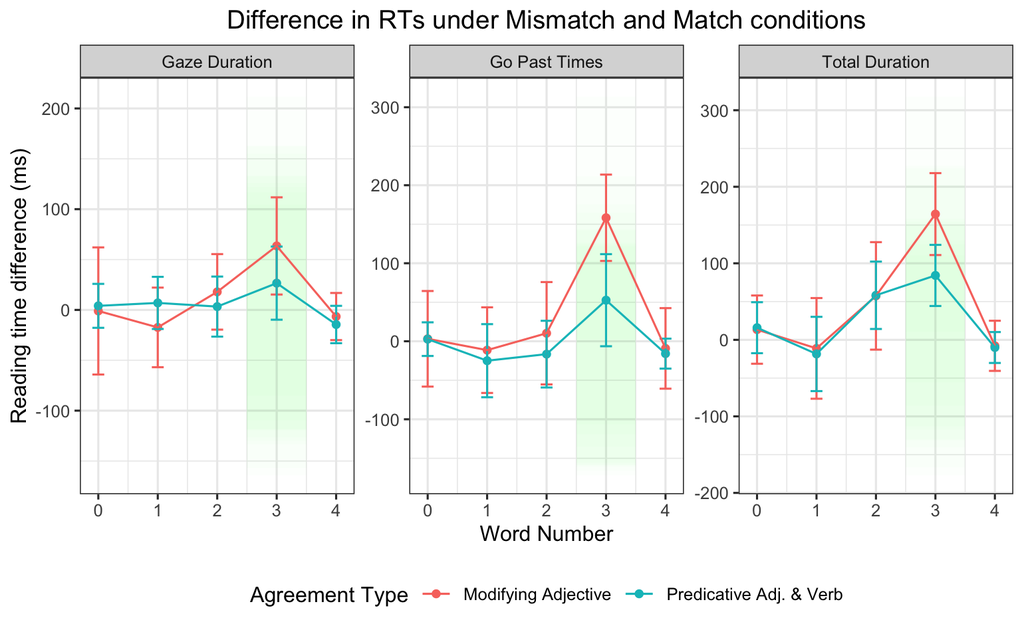

```r
# Plot the reading times in each region broken down by stimulus type, reading measure and target gender

agg_df3 %>%
  # filter(type_s %in% c("stim_adj", "stim_verb", "stim_pred_adj")) %>%
  filter(measure %in% c("gaze_duration", "go_past_time", "total_duration")) %>%

  mutate(type_s = factor(type_s, levels = c("Modifying_Adj", "Predictive_Adj_Verb"), labels=c("Modifying Adjective", "Predicative Adj. & Verb"))) %>%
  mutate(measure = factor(measure, levels = c("gaze_duration", "go_past_time", "total_duration"), labels=c("Gaze Duration", "Go Past Times", "Total Duration"))) %>%

  ggplot(aes(x=region, y=m_diff, color = type_s)) +
    geom_rect(aes(xmin=2.5, xmax=3.5, ymin=lower-100, ymax=upper+100), color = NA, fill = "green", alpha=0.01) +
    geom_point() +
    geom_errorbar(aes(ymin=lower, ymax=upper), width = 0.2) +
    geom_line() +
    facet_wrap(~ measure, scales = "free_y") +
    #ggtitle(paste0("Region by region plot for ", stim)) +
    labs(
      title = "Difference in RTs under Mismatch and Match conditions",
      y = "Reading time difference (ms)",
      x = "Word Number",
      color = "Agreement Type"
    ) +
  theme(
    legend.position = "bottom",
    plot.title = element_text(hjust = 0.5)
  )

ggsave(paste0("./images/RT_results_interaction_in_synt.pdf"), device="pdf", height=5, width=8)
```

```r
# ggsave(paste0("./images/RT_results.png"), height=5, width=8)
```